# Life Expectancy project

By Jinitha. M. J.

USN- 1NT20SDS04

to load the data set

```r
df= read.csv("Life expectancy.csv")
```

to read the head of the dataset

```r
head(df)
```

```
##      Entity Year Life.expectancy
## 1 Australia 1802           34.05
## 2 Australia 1803           34.05
## 3 Australia 1804           34.05
## 4 Australia 1805           34.05
## 5 Australia 1806           34.05
## 6 Australia 1807           34.05
```

To show the number of specified rows i.e for n=8, it will display the first 8 rows

```r
head(df, n=8)
```

```
##      Entity Year Life.expectancy
## 1 Australia 1802           34.05
## 2 Australia 1803           34.05
## 3 Australia 1804           34.05
## 4 Australia 1805           34.05
## 5 Australia 1806           34.05
## 6 Australia 1807           34.05
## 7 Australia 1808           34.05
## 8 Australia 1809           34.05
```

To display the last Rows of your data

```r
tail(df)
```

```
##             Entity Year Life.expectancy
## 3248 United States 2011           78.87
## 3249 United States 2012           78.94
## 3250 United States 2013           78.96
## 3251 United States 2014           78.94
## 3252 United States 2015           78.87
## 3253 United States 2016           78.86
```

To view the previously Loaded named object we use ls() command

```r
ls()
```

```
## [1] "df"
```

for examining the data structure of an object str() command can be used

```r
str(df)
```

```
## 'data.frame':    3253 obs. of  3 variables:
##  $ Entity         : chr  "Australia" "Australia" "Australia" "Australia" ...
##  $ Year           : int  1802 1803 1804 1805 1806 1807 1808 1809 1810 1811 ...
##  $ Life.expectancy: num  34 34 34 34 34 ...
```

```r
df[3,4]
```

[output not shown]

```r
class(df$posttest)
```

```
## [1] "NULL"
```

```r
class(dimnames(df))
```

```
## [1] "list"
```

to show a different number of rows

```r
head(df, n=7)
```

```
##      Entity Year Life.expectancy
## 1 Australia 1802           34.05
## 2 Australia 1803           34.05
## 3 Australia 1804           34.05
## 4 Australia 1805           34.05
## 5 Australia 1806           34.05
## 6 Australia 1807           34.05
## 7 Australia 1808           34.05
```

to display the bottom 6 lines in the data

```r
tail(df)
```

```
##             Entity Year Life.expectancy
## 3248 United States 2011           78.87
## 3249 United States 2012           78.94
## 3250 United States 2013           78.96
## 3251 United States 2014           78.94
## 3252 United States 2015           78.87
## 3253 United States 2016           78.86
```

to show a different number of rows

```r
tail(df, n=5)
```

```
##             Entity Year Life.expectancy
## 3249 United States 2012           78.94
## 3250 United States 2013           78.96
## 3251 United States 2014           78.94
## 3252 United States 2015           78.87
## 3253 United States 2016           78.86
```

To get summary about an Data frame and particular columns

```r
summary(df)
```

```
##     Entity               Year      Life.expectancy
##  Length:3253        Min.   :1800   Min.   : 8.109
##  Class :character   1st Qu.:1854   1st Qu.:32.000
##  Mode  :character   Median :1908   Median :41.880
##                     Mean   :1908   Mean   :48.680
##                     3rd Qu.:1962   3rd Qu.:66.820
##                     Max.   :2016   Max.   :83.940
```

to return the structure of the given object with further attributes set

```r
head(structure(df))
```

```
##      Entity Year Life.expectancy
## 1 Australia 1802           34.05
## 2 Australia 1803           34.05
## 3 Australia 1804           34.05
## 4 Australia 1805           34.05
## 5 Australia 1806           34.05
## 6 Australia 1807           34.05
```

to view all the named objects you have at once

```r
ls.str(df)
```

```
## Entity :  chr [1:3253] "Australia" "Australia" "Australia" "Australia" "Australia" ...
## Life.expectancy :  num [1:3253] 34 34 34 34 34 ...
## Year :  int [1:3253] 1802 1803 1804 1805 1806 1807 1808 1809 1810 1811 ...
```

used to narrow down your focus

```r
ls.str(pattern = 'df')
```

```
## df : 'data.frame':   3253 obs. of  3 variables:
##  $ Entity         : chr  "Australia" "Australia" "Australia" "Australia" ...
##  $ Year           : int  1802 1803 1804 1805 1806 1807 1808 1809 1810 1811 ...
##  $ Life.expectancy: num  34 34 34 34 34 ...
```

to view all the columns or rows

```r
names(df)
```

```
## [1] "Entity"          "Year"            "Life.expectancy"
```

to view all the rows

```r
row.names(df)
```

```
##    [1] "1"    "2"    "3"    "4"    "5"    "6"    "7"    "8"    "9"    "10"
##   [11] "11"   "12"   "13"   "14"   "15"   "16"   "17"   "18"   "19"   "20"
##   [21] "21"   "22"   "23"   "24"   "25"   "26"   "27"   "28"   "29"   "30"
##   [31] "31"   "32"   "33"   "34"   "35"   "36"   "37"   "38"   "39"   "40"
##   [41] "41"   "42"   "43"   "44"   "45"   "46"   "47"   "48"   "49"   "50"
##   [51] "51"   "52"   "53"   "54"   "55"   "56"   "57"   "58"   "59"   "60"
##   [61] "61"   "62"   "63"   "64"   "65"   "66"   "67"   "68"   "69"   "70"
##   [71] "71"   "72"   "73"   "74"   "75"   "76"   "77"   "78"   "79"   "80"
##   [81] "81"   "82"   "83"   "84"   "85"   "86"   "87"   "88"   "89"   "90"
##   [91] "91"   "92"   "93"   "94"   "95"   "96"   "97"   "98"   "99"   "100"
##  [101] "101"  "102"  "103"  "104"  "105"  "106"  "107"  "108"  "109"  "110"
##  [111] "111"  "112"  "113"  "114"  "115"  "116"  "117"  "118"  "119"  "120"
##  [121] "121"  "122"  "123"  "124"  "125"  "126"  "127"  "128"  "129"  "130"
##  [131] "131"  "132"  "133"  "134"  "135"  "136"  "137"  "138"  "139"  "140"
##  [141] "141"  "142"  "143"  "144"  "145"  "146"  "147"  "148"  "149"  "150"
```

[output cut: 311 more lines]

to represent names of all the coloumns

```r
colnames(df)
```

```
## [1] "Entity"          "Year"            "Life.expectancy"
```

To see both rows and columns names at the once

```r
dimnames(df)
```

```
## [[1]]
##    [1] "1"    "2"    "3"    "4"    "5"    "6"    "7"    "8"    "9"    "10"
##   [11] "11"   "12"   "13"   "14"   "15"   "16"   "17"   "18"   "19"   "20"
##   [21] "21"   "22"   "23"   "24"   "25"   "26"   "27"   "28"   "29"   "30"
##   [31] "31"   "32"   "33"   "34"   "35"   "36"   "37"   "38"   "39"   "40"
##   [41] "41"   "42"   "43"   "44"   "45"   "46"   "47"   "48"   "49"   "50"
##   [51] "51"   "52"   "53"   "54"   "55"   "56"   "57"   "58"   "59"   "60"
##   [61] "61"   "62"   "63"   "64"   "65"   "66"   "67"   "68"   "69"   "70"
##   [71] "71"   "72"   "73"   "74"   "75"   "76"   "77"   "78"   "79"   "80"
##   [81] "81"   "82"   "83"   "84"   "85"   "86"   "87"   "88"   "89"   "90"
##   [91] "91"   "92"   "93"   "94"   "95"   "96"   "97"   "98"   "99"   "100"
##  [101] "101"  "102"  "103"  "104"  "105"  "106"  "107"  "108"  "109"  "110"
##  [111] "111"  "112"  "113"  "114"  "115"  "116"  "117"  "118"  "119"  "120"
##  [121] "121"  "122"  "123"  "124"  "125"  "126"  "127"  "128"  "129"  "130"
##  [131] "131"  "132"  "133"  "134"  "135"  "136"  "137"  "138"  "139"  "140"
```

[output cut: 315 more lines]

to determine the number of items in an object

```r
length(df)
```

```
## [1] 3
```

```r
tdf = attach(df)
tdf
```

```
## <environment: 0x00000000150523b0>
## attr(,"name")
## [1] "df"
```

```r
head(stack(df))
```

```
##      values    ind
## 1 Australia Entity
## 2 Australia Entity
## 3 Australia Entity
## 4 Australia Entity
## 5 Australia Entity
## 6 Australia Entity
```

to get the index

```r
head(order(df$Year))
```

```
## [1]  216  433  650  867 1084 1301
```

to identify the class of a column

```r
class(df$Year)
```

```
## [1] "integer"
```

Summary of a column

```r
summary(df$Year)
```

```
##    Min. 1st Qu.  Median    Mean 3rd Qu.    Max.
##    1800    1854    1908    1908    1962    2016
```

To find the mean of a column

```r
mean(df$Year)
```

```
## [1] 1908.066
```

To find the median of a column

```r
median(df$Year)
```

```
## [1] 1908
```

to find the median absolute deviation

```r
mad(df$Year)
```

```
## [1] 80.0604
```

to find the mode absolute deviation

```r
mode(df$Year)
```

```
## [1] "numeric"
```

to find the variance absolute deviation

```r
var(df$Year)
```

```
## [1] 3920.508
```

to find the sd absolute deviation

```r
sd(df$Year)
```

```
## [1] 62.61396
```

to find the quartile absolute deviation

```r
quantile(df$Year)
```

```
##   0%  25%  50%  75% 100%
## 1800 1854 1908 1962 2016
```

Returns a five number summary

```r
fivenum(df$Year)
```

```
## [1] 1800 1854 1908 1962 2016
```

```r
df$Year[3]
```

```
## [1] 1804
```

```r
df$Year[1:5]
```

```
## [1] 1802 1803 1804 1805 1806
```

To find the max and min numeric object

```r
max(df$Year)
```

```
## [1] 2016
```

```r
min(df$Year)
```

```
## [1] 1800
```

sort in ascending order

```r
head(sort(df$Year))
```

```
## [1] 1800 1800 1800 1800 1800 1800
```

```r
min(df$Life.expectancy)
```

```
## [1] 8.108836
```

```r
head(sort(df$Life.expectancy))
```

```
## [1]  8.108836 16.000000 17.350000 18.000000 18.000000 18.186424
```

to Compare Two Variances

```r
var.test(df$Year, df$Life.expectancy)
```

```
##
##  F test to compare two variances
##
## data:  df$Year and df$Life.expectancy
## F = 12.147, num df = 3252, denom df = 3252, p-value < 2.2e-16
## alternative hypothesis: true ratio of variances is not equal to 1
## 95 percent confidence interval:
##  11.33959 13.01109
## sample estimates:
## ratio of variances
##           12.14662
```

to get an index

```r
head(order(df$Year))
```

```
## [1]  216  433  650  867 1084 1301
```

to get the rank

```r
head(rank(df$Year), n=10)
```

```
##  [1]  36  51  66  81  96 111 126 141 156 171
```

to display the selceted rows and colomns

```r
df[3,3]
```

```
## [1] 34.05
```

```r
df[3, 1:2]
```

```
##      Entity Year
## 3 Australia 1804
```

```r
df[3, 2:3]
```

```
##   Year Life.expectancy
## 3 1804           34.05
```

to covert data frame to matrix

```r
head(as.matrix(df))
```

```
##      Entity      Year   Life.expectancy
## [1,] "Australia" "1802" "34.049999"
## [2,] "Australia" "1803" "34.049999"
## [3,] "Australia" "1804" "34.049999"
## [4,] "Australia" "1805" "34.049999"
## [5,] "Australia" "1806" "34.049999"
## [6,] "Australia" "1807" "34.049999"
```

to assemble a matrix/data frames

```r
head(rbind(df))
```

```
##      Entity Year Life.expectancy
## 1 Australia 1802           34.05
## 2 Australia 1803           34.05
## 3 Australia 1804           34.05
## 4 Australia 1805           34.05
## 5 Australia 1806           34.05
## 6 Australia 1807           34.05
```

```r
head(cbind(df))
```

```
##      Entity Year Life.expectancy
## 1 Australia 1802           34.05
## 2 Australia 1803           34.05
## 3 Australia 1804           34.05
## 4 Australia 1805           34.05
## 5 Australia 1806           34.05
## 6 Australia 1807           34.05
```

Cumulative Commands

```r
head(cumsum(df$Year))
```

```
## [1]  1802  3605  5409  7214  9020 10827
```

```r
head(cumsum(df$Life.expectancy))
```

```
## [1]  34.05  68.10 102.15 136.20 170.25 204.30
```

```r
head(cummin(df$Year))
```

```
## [1] 1802 1802 1802 1802 1802 1802
```

```r
head(cummin(df$Life.expectancy))
```

```
## [1] 34.05 34.05 34.05 34.05 34.05 34.05
```

```r
head(cumprod(df$Year))
```

```
## [1] 1.802000e+03 3.249006e+06 5.861207e+09 1.057948e+13 1.910654e+16
## [6] 3.452551e+19
```

to specify which columns of data you want to use to create your contingency table

```r
table(df$Year)
```

```
##
## 1800 1801 1802 1803 1804 1805 1806 1807 1808 1809 1810 1811 1812 1813 1814 1815
##   14   14   15   15   15   15   15   15   15   15   15   15   15   15   15   15
## 1816 1817 1818 1819 1820 1821 1822 1823 1824 1825 1826 1827 1828 1829 1830 1831
##   15   15   15   15   15   15   15   15   15   15   15   15   15   15   15   15
## 1832 1833 1834 1835 1836 1837 1838 1839 1840 1841 1842 1843 1844 1845 1846 1847
##   15   15   15   15   15   15   15   15   15   15   15   15   15   15   15   15
## 1848 1849 1850 1851 1852 1853 1854 1855 1856 1857 1858 1859 1860 1861 1862 1863
##   15   15   15   15   15   15   15   15   15   15   15   15   15   15   15   15
## 1864 1865 1866 1867 1868 1869 1870 1871 1872 1873 1874 1875 1876 1877 1878 1879
##   15   15   15   15   15   15   15   15   15   15   15   15   15   15   15   15
## 1880 1881 1882 1883 1884 1885 1886 1887 1888 1889 1890 1891 1892 1893 1894 1895
##   15   15   15   15   15   15   15   15   15   15   15   15   15   15   15   15
## 1896 1897 1898 1899 1900 1901 1902 1903 1904 1905 1906 1907 1908 1909 1910 1911
##   15   15   15   15   15   15   15   15   15   15   15   15   15   15   15   15
## 1912 1913 1914 1915 1916 1917 1918 1919 1920 1921 1922 1923 1924 1925 1926 1927
##   15   15   15   15   15   15   15   15   15   15   15   15   15   15   15   15
## 1928 1929 1930 1931 1932 1933 1934 1935 1936 1937 1938 1939 1940 1941 1942 1943
##   15   15   15   15   15   15   15   15   15   15   15   15   15   15   15   15
## 1944 1945 1946 1947 1948 1949 1950 1951 1952 1953 1954 1955 1956 1957 1958 1959
##   15   15   15   15   15   15   15   15   15   15   15   15   15   15   15   15
## 1960 1961 1962 1963 1964 1965 1966 1967 1968 1969 1970 1971 1972 1973 1974 1975
##   15   15   15   15   15   15   15   15   15   15   15   15   15   15   15   15
## 1976 1977 1978 1979 1980 1981 1982 1983 1984 1985 1986 1987 1988 1989 1990 1991
##   15   15   15   15   15   15   15   15   15   15   15   15   15   15   15   15
## 1992 1993 1994 1995 1996 1997 1998 1999 2000 2001 2002 2003 2004 2005 2006 2007
##   15   15   15   15   15   15   15   15   15   15   15   15   15   15   15   15
## 2008 2009 2010 2011 2012 2013 2014 2015 2016
##   15   15   15   15   15   15   15   15   15
```

```r
head(as.table(df$Year))
```

```
##    A    B    C    D    E    F
## 1802 1803 1804 1805 1806 1807
```

to check if dataframe is extracted

```r
is.data.frame(df)
```

```
## [1] TRUE
```

```r
is.table(df)
```

```
## [1] FALSE
```

to form the basis of a logical test

```r
if(class(df) == 'data.frame') TRUE else FALSE
```

```
## [1] TRUE
```

to creates a simple index

```r
seq_along(df)
```

```
## [1] 1 2 3
```

to create a basic stem and leaf plot

```r
stem(df$Year)
```

```
##
##   The decimal point is 1 digit(s) to the right of the |
##
##   180 | 00000000000000111111111111112222222222222223333333333333334444444444+68
##   181 | 00000000000000011111111111111122222222222222233333333333333344444444+70
##   182 | 00000000000000011111111111111122222222222222233333333333333344444444+70
##   183 | 00000000000000011111111111111122222222222222233333333333333344444444+70
##   184 | 00000000000000011111111111111122222222222222233333333333333344444444+70
##   185 | 00000000000000011111111111111122222222222222233333333333333344444444+70
##   186 | 00000000000000011111111111111122222222222222233333333333333344444444+70
##   187 | 00000000000000011111111111111122222222222222233333333333333344444444+70
##   188 | 00000000000000011111111111111122222222222222233333333333333344444444+70
##   189 | 00000000000000011111111111111122222222222222233333333333333344444444+70
##   190 | 00000000000000011111111111111122222222222222233333333333333344444444+70
##   191 | 00000000000000011111111111111122222222222222233333333333333344444444+70
##   192 | 00000000000000011111111111111122222222222222233333333333333344444444+70
##   193 | 00000000000000011111111111111122222222222222233333333333333344444444+70
##   194 | 00000000000000011111111111111122222222222222233333333333333344444444+70
##   195 | 00000000000000011111111111111122222222222222233333333333333344444444+70
##   196 | 00000000000000011111111111111122222222222222233333333333333344444444+70
##   197 | 00000000000000011111111111111122222222222222233333333333333344444444+70
##   198 | 00000000000000011111111111111122222222222222233333333333333344444444+70
##   199 | 00000000000000011111111111111122222222222222233333333333333344444444+70
##   200 | 00000000000000011111111111111122222222222222233333333333333344444444+70
##   201 | 00000000000000011111111111111122222222222222233333333333333344444444+25
```

to increase the number of bins

```r
stem(df$Year, scale = 2)
```

```
##
##   The decimal point is 1 digit(s) to the right of the |
##
##   180 | 00000000000000111111111111112222222222222223333333333333334444444444+68
##   181 | 00000000000000011111111111111122222222222222233333333333333344444444+70
##   182 | 00000000000000011111111111111122222222222222233333333333333344444444+70
##   183 | 00000000000000011111111111111122222222222222233333333333333344444444+70
##   184 | 00000000000000011111111111111122222222222222233333333333333344444444+70
##   185 | 00000000000000011111111111111122222222222222233333333333333344444444+70
##   186 | 00000000000000011111111111111122222222222222233333333333333344444444+70
##   187 | 00000000000000011111111111111122222222222222233333333333333344444444+70
##   188 | 00000000000000011111111111111122222222222222233333333333333344444444+70
##   189 | 00000000000000011111111111111122222222222222233333333333333344444444+70
##   190 | 00000000000000011111111111111122222222222222233333333333333344444444+70
##   191 | 00000000000000011111111111111122222222222222233333333333333344444444+70
##   192 | 00000000000000011111111111111122222222222222233333333333333344444444+70
##   193 | 00000000000000011111111111111122222222222222233333333333333344444444+70
##   194 | 00000000000000011111111111111122222222222222233333333333333344444444+70
##   195 | 00000000000000011111111111111122222222222222233333333333333344444444+70
##   196 | 00000000000000011111111111111122222222222222233333333333333344444444+70
##   197 | 00000000000000011111111111111122222222222222233333333333333344444444+70
##   198 | 00000000000000011111111111111122222222222222233333333333333344444444+70
##   199 | 00000000000000011111111111111122222222222222233333333333333344444444+70
##   200 | 00000000000000011111111111111122222222222222233333333333333344444444+70
##   201 | 00000000000000011111111111111122222222222222233333333333333344444444+25
```

to create a Histogram

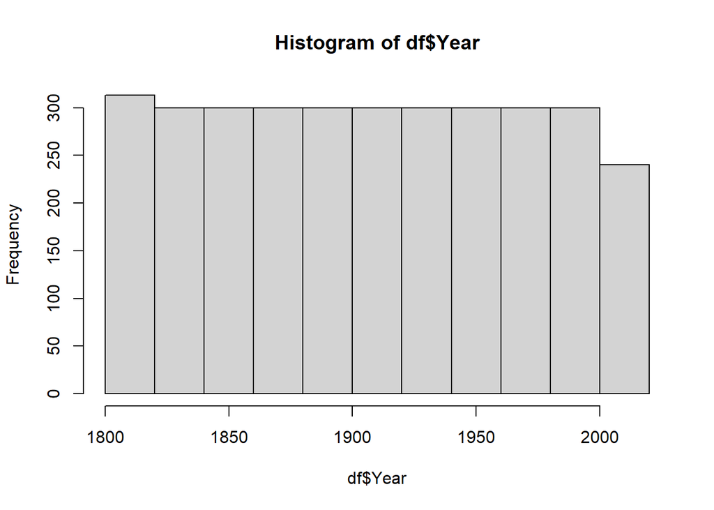

```r
hist(df$Year)
```

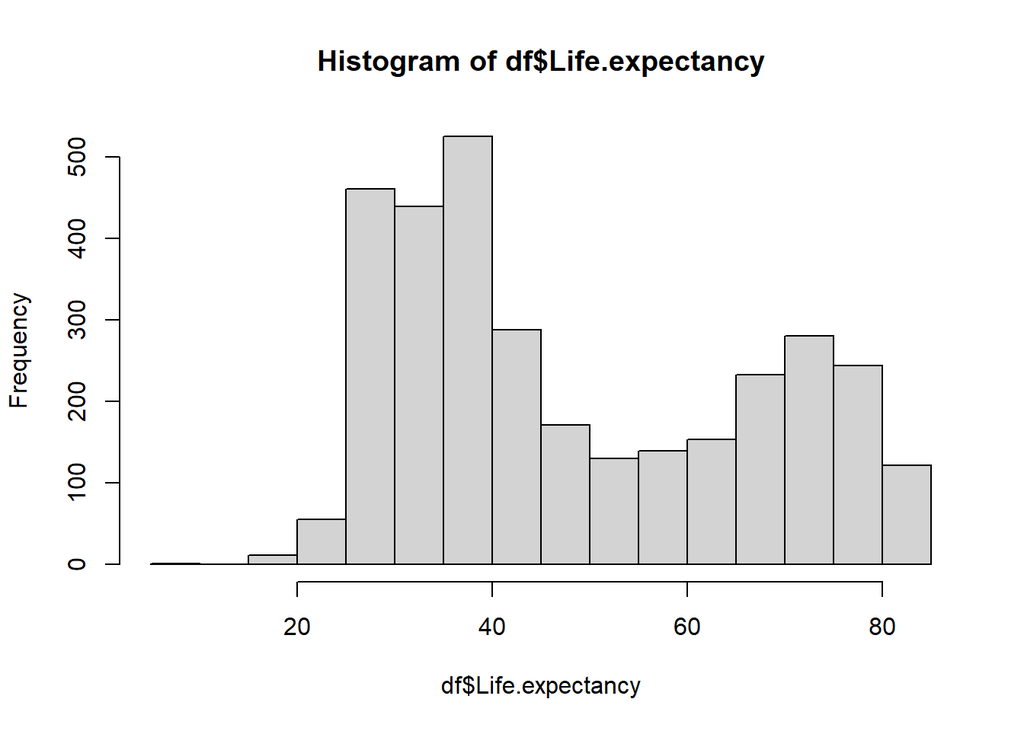

```r
hist(df$Life.expectancy)
```

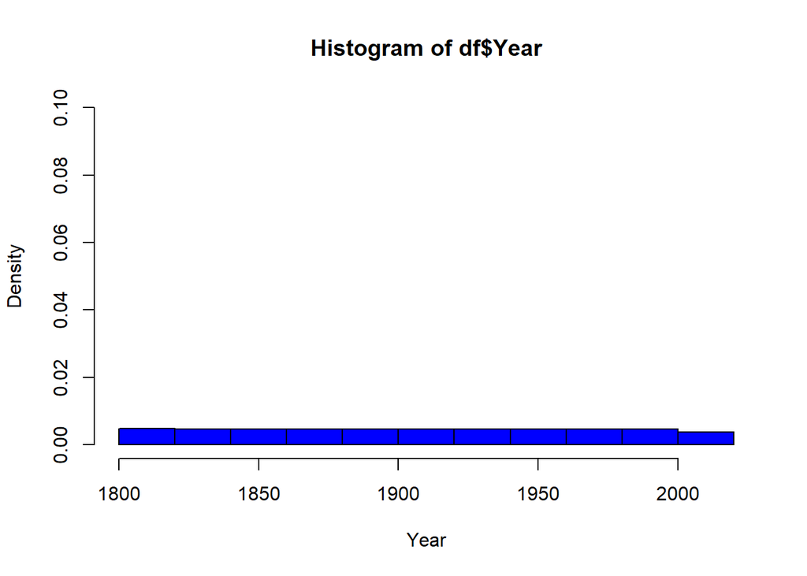

```r
hist(df$Year, col = 'blue', xlab = 'Year', ylim = c(0, 0.1), freq = FALSE)
```

to find the density

```r
density(df$Year)
```

```
##
## Call:
##  density.default(x = df$Year)
##
## Data: df$Year (3253 obs.);   Bandwidth 'bw' = 11.18
##
##        x              y
##  Min.   :1766   Min.   :7.096e-06
##  1st Qu.:1837   1st Qu.:2.663e-03
##  Median :1908   Median :4.614e-03
##  Mean   :1908   Mean   :3.529e-03
##  3rd Qu.:1979   3rd Qu.:4.616e-03
##  Max.   :2050   Max.   :4.616e-03
```

Density Function to Draw a Graph

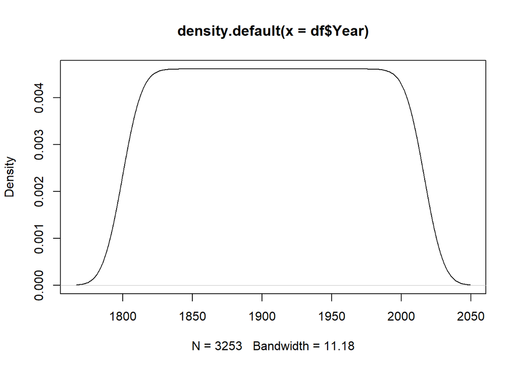

```r
plot(density(df$Year))
```

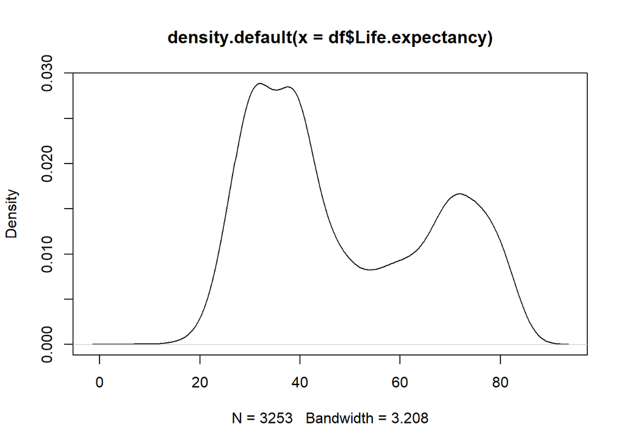

```r
plot(density(df$Life.expectancy))
```

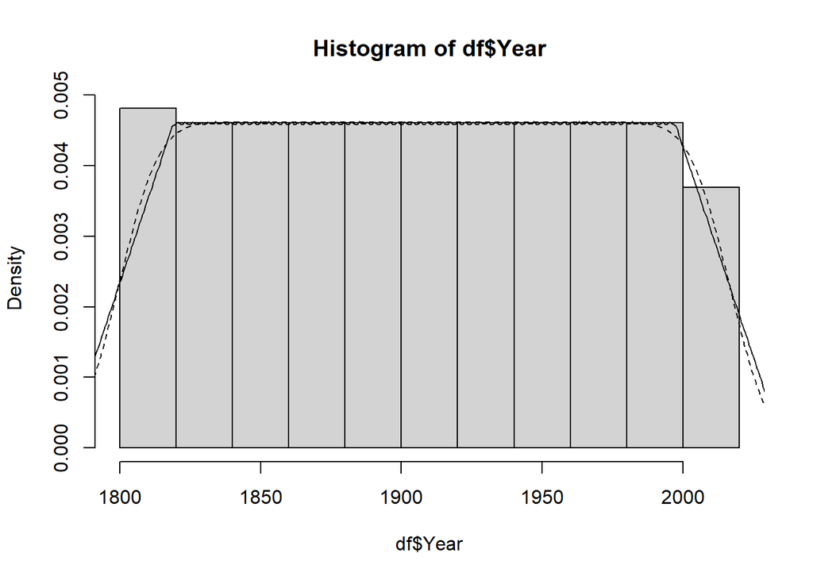

```r
hist(df$Year, freq = F)
lines(density(df$Year), lty = 2)
lines(density(df$Year, k = 'rectangular'))
```

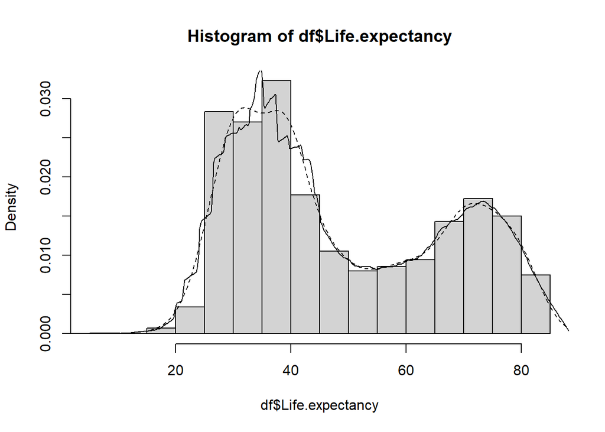

```r
hist(df$Life.expectancy, freq = F)
lines(density(df$Life.expectancy), lty = 2)
lines(density(df$Life.expectancy, k = 'rectangular'))
```

to generate n random numbers from the normal distribution

```r
head(rnorm(df$Year, mean = 0, sd = 1))
```

```
## [1] -0.4995932 -0.1758945  0.7080973  0.3124962 -1.3898396 -2.6263225
```

Returns the probability for the quantile q

```r
head(pnorm(df$Year, mean = 0, sd = 1))
```

```
## [1] 1 1 1 1 1 1
```

Returns the quantile for a given probability p

```r
head(qnorm(df$Year, mean = 0, sd = 1))
```

```
## [1] NaN NaN NaN NaN NaN NaN
```

Gives the density function for values x

```r
head(dnorm(df$Year, mean = 0, sd = 1))
```

```
## [1] 0 0 0 0 0 0
```

Quantile-Quantile Plot

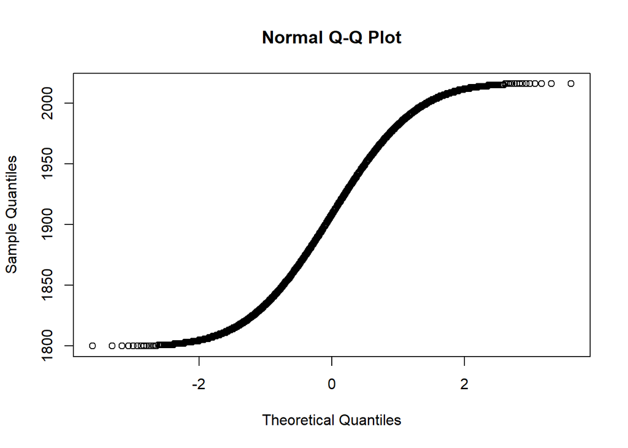

```r
qqnorm(df$Year)
```

Quantile-Quantile Plot

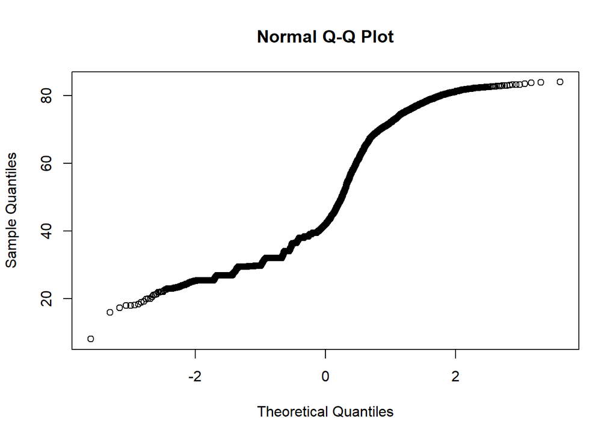

```r
qqnorm(df$Life.expectancy)
```

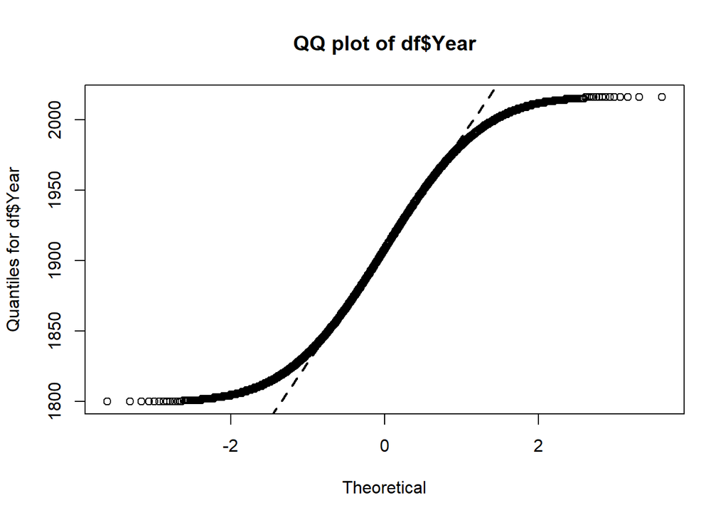

```r
qqnorm(df$Year, main = 'QQ plot of df$Year', xlab = 'Theoretical',
ylab = 'Quantiles for df$Year')
qqline(df$Year, lwd = 2, lty = 2)
```

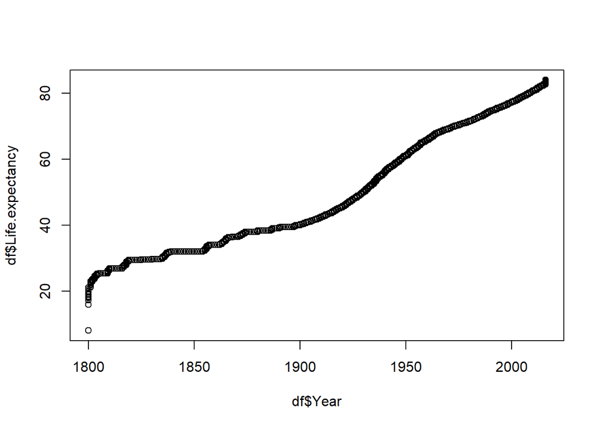

```r
qqplot(df$Year, df$Life.expectancy)
```

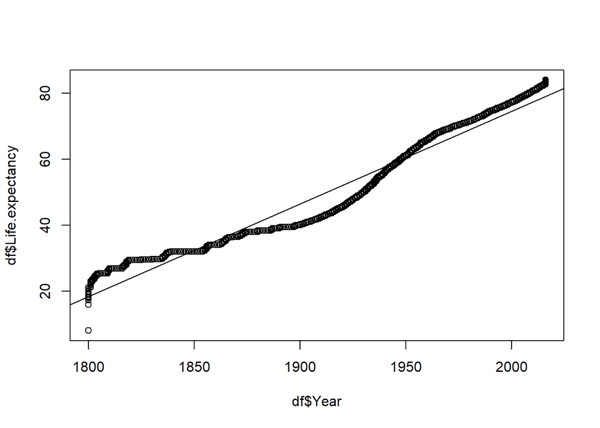

```r
qqp = qqplot(df$Year, df$Life.expectancy)
abline(lm(qqp$y ~ qqp$x))
```

```r
t.test(df$Year, df$Life.expectancy)
```

```
##
##  Welch Two Sample t-test
##
## data:  df$Year and df$Life.expectancy
## t = 1628, df = 3783.9, p-value < 2.2e-16
## alternative hypothesis: true difference in means is not equal to 0
## 95 percent confidence interval:
##  1857.146 1861.625
## sample estimates:
##  mean of x  mean of y
## 1908.06609   48.68038
```

```r
t.test(df$Year, df$Life.expectancy, var.equal = TRUE)
```

```
##
##  Two Sample t-test
##
## data:  df$Year and df$Life.expectancy
## t = 1628, df = 6504, p-value < 2.2e-16
## alternative hypothesis: true difference in means is not equal to 0
## 95 percent confidence interval:
##  1857.147 1861.625
## sample estimates:
##  mean of x  mean of y
## 1908.06609   48.68038
```

```r
t.test(df$Year, mu = 5)
```

```
##
##  One Sample t-test
##
## data:  df$Year
## t = 1733.5, df = 3252, p-value < 2.2e-16
## alternative hypothesis: true mean is not equal to 5
## 95 percent confidence interval:
##  1905.914 1910.219
## sample estimates:
## mean of x
##  1908.066
```

```r
t.test(df$Life.expectancy, mu = 5)
```

```
##
##  One Sample t-test
##
## data:  df$Life.expectancy
## t = 138.67, df = 3252, p-value < 2.2e-16
## alternative hypothesis: true mean is not equal to 5
## 95 percent confidence interval:
##  48.06277 49.29799
## sample estimates:
## mean of x
##  48.68038
```

Using Directional Hypotheses

```r
t.test(df$Year, mu = 5, alternative = 'greater')
```

```
##
##  One Sample t-test
##
## data:  df$Year
## t = 1733.5, df = 3252, p-value < 2.2e-16
## alternative hypothesis: true mean is greater than 5
## 95 percent confidence interval:
##  1906.26     Inf
## sample estimates:
## mean of x
##  1908.066
```

Using Directional Hypotheses

```r
t.test(df$Life.expectancy, mu = 5, alternative = 'greater')
```

```
##
##  One Sample t-test
##
## data:  df$Life.expectancy
## t = 138.67, df = 3252, p-value < 2.2e-16
## alternative hypothesis: true mean is greater than 5
## 95 percent confidence interval:
##  48.16211      Inf
## sample estimates:
## mean of x
##  48.68038
```

formula Syntax and Subsetting Samples in the t-Test

```r
t.test(df$Year ~ df$Entity, data = df, subset = df$Entity %in% c('Australia' , 'Brazil'))
```

```
##
##  Welch Two Sample t-test
##
## data:  df$Year by df$Entity
## t = 0.16628, df = 430, p-value = 0.868
## alternative hypothesis: true difference in means between group Australia and group Brazil is not equal to 0
## 95 percent confidence interval:
##  -10.82024  12.82024
## sample estimates:
## mean in group Australia    mean in group Brazil
##                    1909                    1908
```

```r
t.test(df$Year ~ df$Entity, data = df, subset = df$Entity %in% c('Australia' , 'Canada'))
```

```
##
##  Welch Two Sample t-test
##
## data:  df$Year by df$Entity
## t = 0.16628, df = 430, p-value = 0.868
## alternative hypothesis: true difference in means between group Australia and group Canada is not equal to 0
## 95 percent confidence interval:
##  -10.82024  12.82024
## sample estimates:
## mean in group Australia    mean in group Canada
##                    1909                    1908
```

```r
t.test(df$Year ~ df$Entity, data = df, subset = df$Entity %in% c('Canada' , 'Brazil'))
```

```
##
##  Welch Two Sample t-test
##
## data:  df$Year by df$Entity
## t = 0, df = 432, p-value = 1
## alternative hypothesis: true difference in means between group Brazil and group Canada is not equal to 0
## 95 percent confidence interval:
##  -11.84729  11.84729
## sample estimates:
## mean in group Brazil mean in group Canada
##                 1908                 1908
```

Two-Sample U-Test

```r
wilcox.test(df$Year, df$Life.expectancy)
```

```
##
##  Wilcoxon rank sum test with continuity correction
##
## data:  df$Year and df$Life.expectancy
## W = 10582009, p-value < 2.2e-16
## alternative hypothesis: true location shift is not equal to 0
```

basic correlation between x and y

```r
cor(df$Year, df$Life.expectancy)
```

```
## [1] 0.8438424
```

Determines covariance between x and y

```r
x = cov(df$Year, df$Life.expectancy)
x
```

```
## [1] 949.2398
```

to determine the correlation from a matrix of covariance

```r
v = as.matrix(x)
cov2cor(v)
```

```
##      [,1]
## [1,]    1
```

Significance Testing in Correlation Tests

```r
cor.test(df$Year, df$Life.expectancy)
```

```
##
##  Pearson's product-moment correlation
##
## data:  df$Year and df$Life.expectancy
## t = 89.666, df = 3251, p-value < 2.2e-16
## alternative hypothesis: true correlation is not equal to 0
## 95 percent confidence interval:
##  0.8336517 0.8534587
## sample estimates:
##       cor
## 0.8438424
```

```r
chisq.test(df$Year
           )
```

```
##
##  Chi-squared test for given probabilities
##
## data:  df$Year
## X-squared = 6681.9, df = 3252, p-value < 2.2e-16
```

```r
chisq.test(df$Life.expectancy)
```

```
##
##  Chi-squared test for given probabilities
##
## data:  df$Life.expectancy
## X-squared = 21562, df = 3252, p-value < 2.2e-16
```

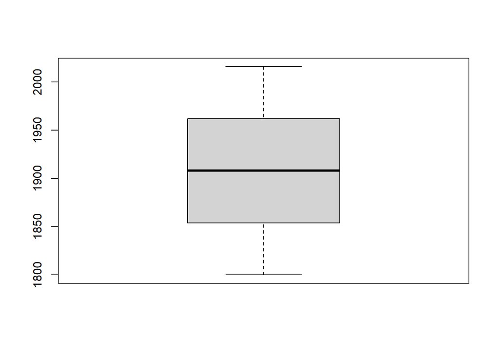

```r
boxplot(df$Year)
```

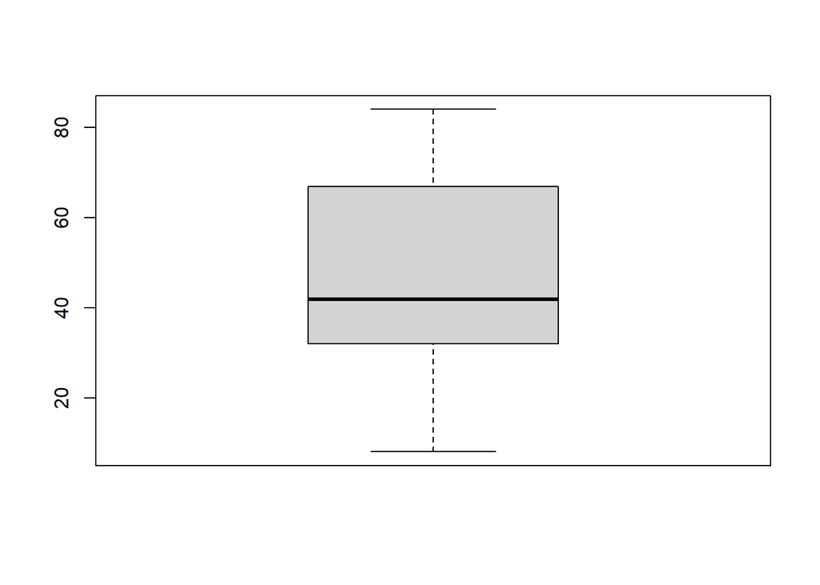

```r
boxplot(df$Life.expectancy)
```

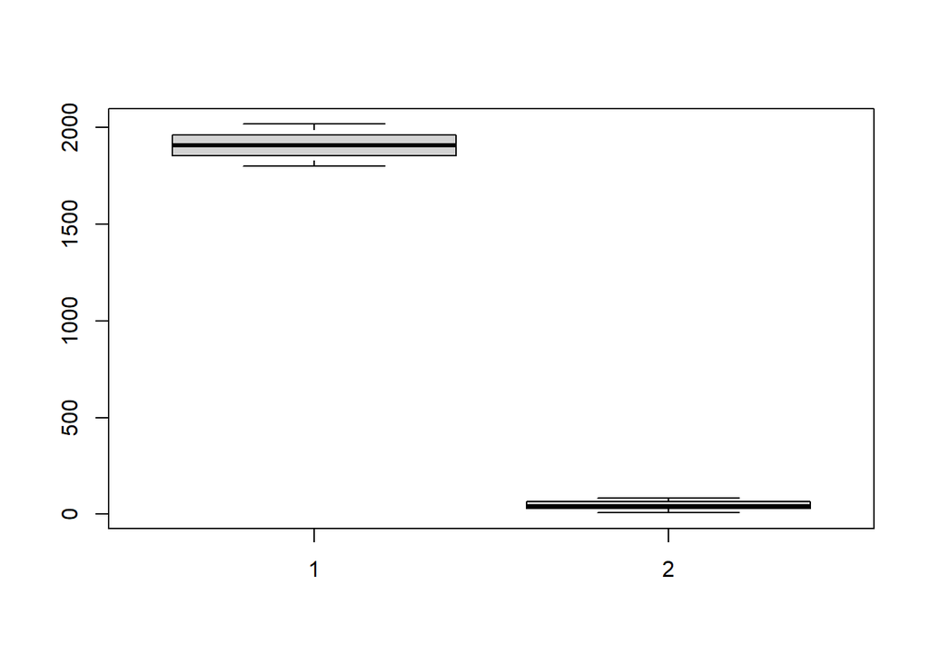

```r
boxplot(df$Year, df$Life.expectancy)
```

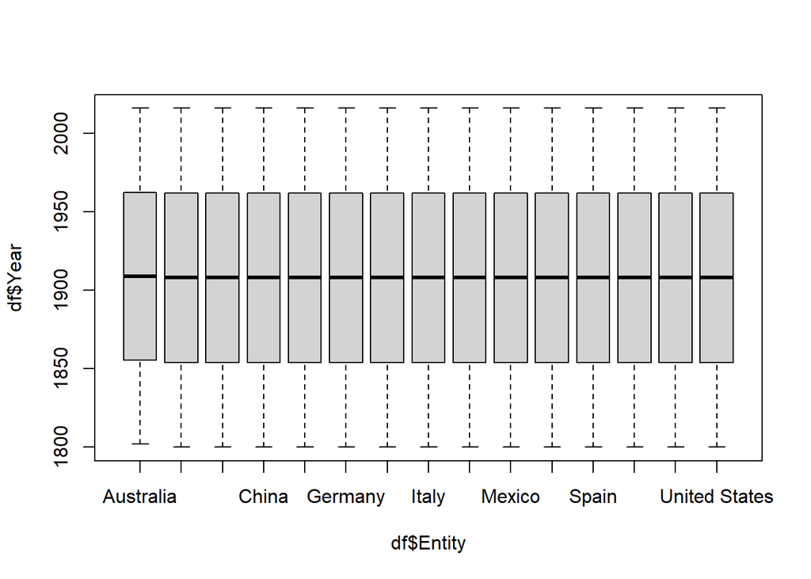

```r
boxplot(df$Year ~ df$Entity, data = df)
```

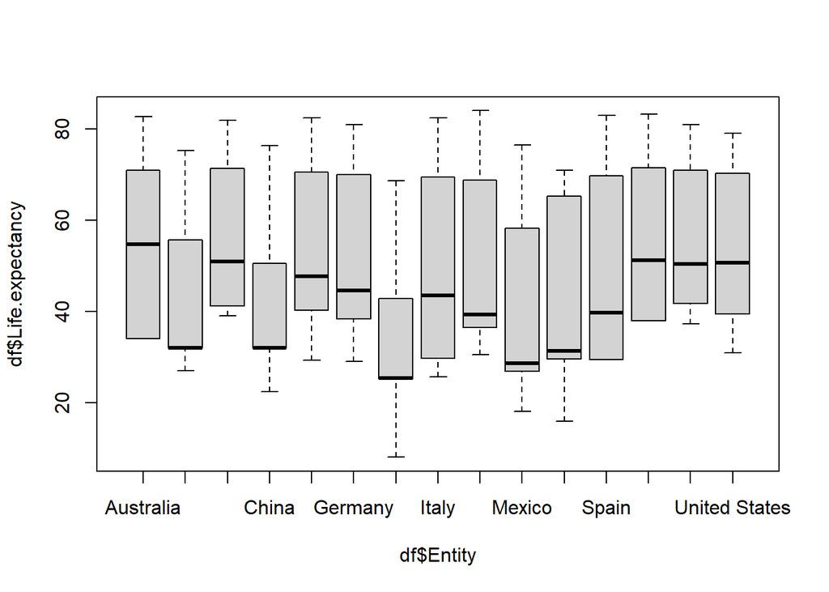

```r
boxplot(df$Life.expectancy ~ df$Entity, data = df)
```

Horizontal Boxplots

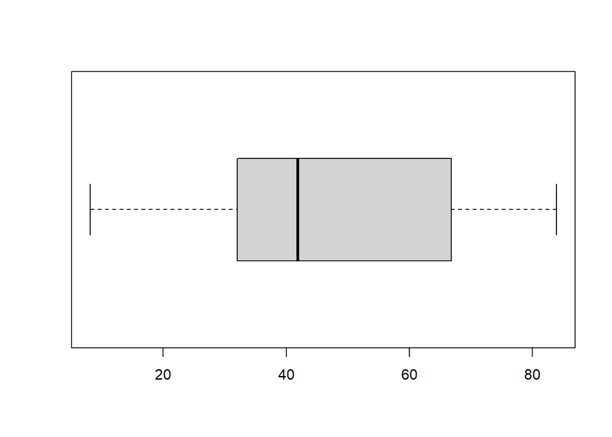

```r
boxplot(df$Life.expectancy, horizontal = T)
```

with title

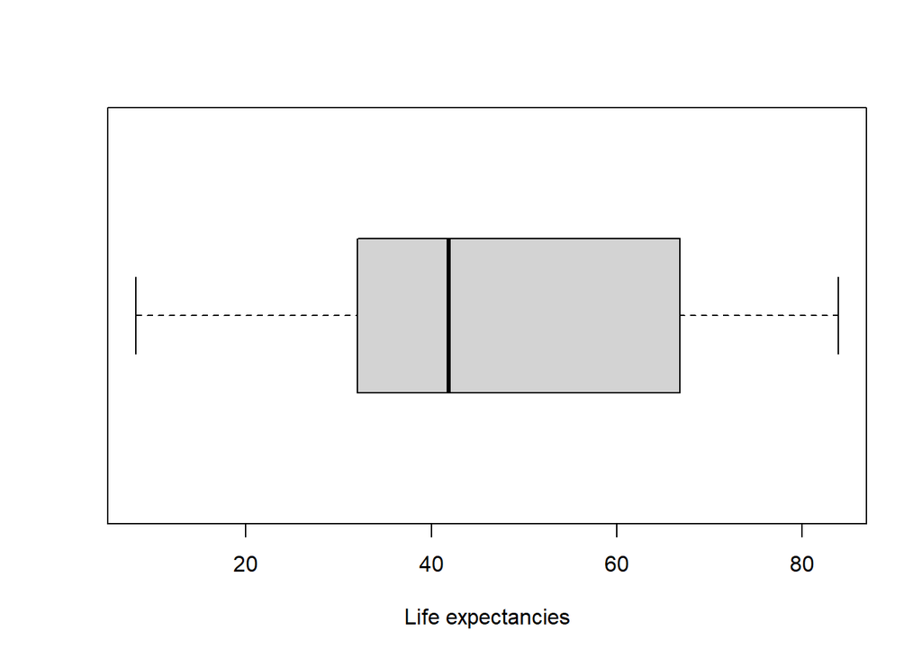

```r
boxplot(df$Life.expectancy, horizontal = T)
title(xlab = 'Life expectancies')
```

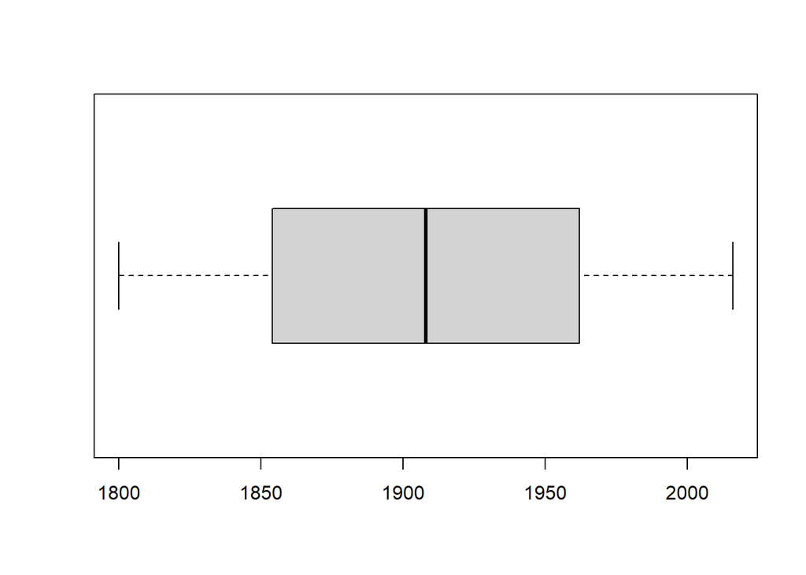

```r
boxplot(df$Year, horizontal = T)
```

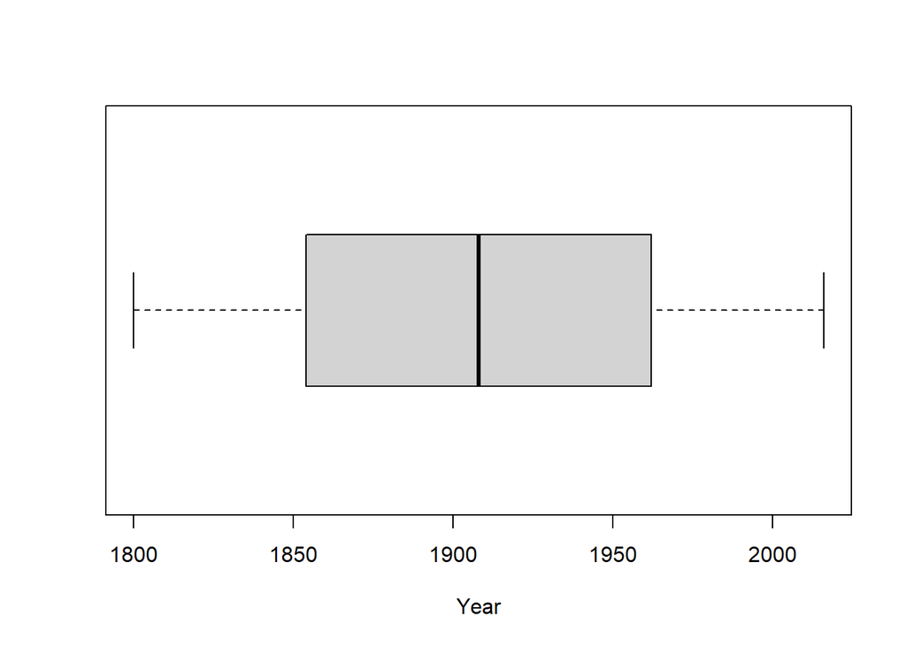

```r
boxplot(df$Year, horizontal = T)
title(xlab = 'Year')
```

```r
library(dplyr)
```

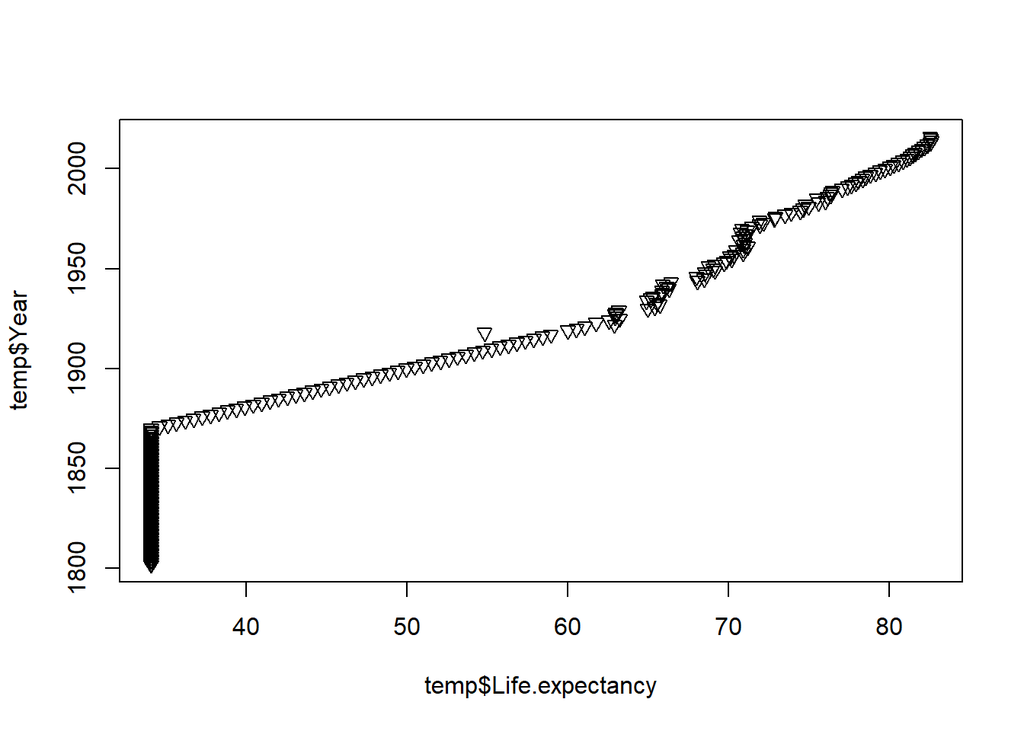

```r
temp = df %>% filter(df$Entity == "Australia")
plot(temp$Life.expectancy, temp$Year, pch = 25)
```

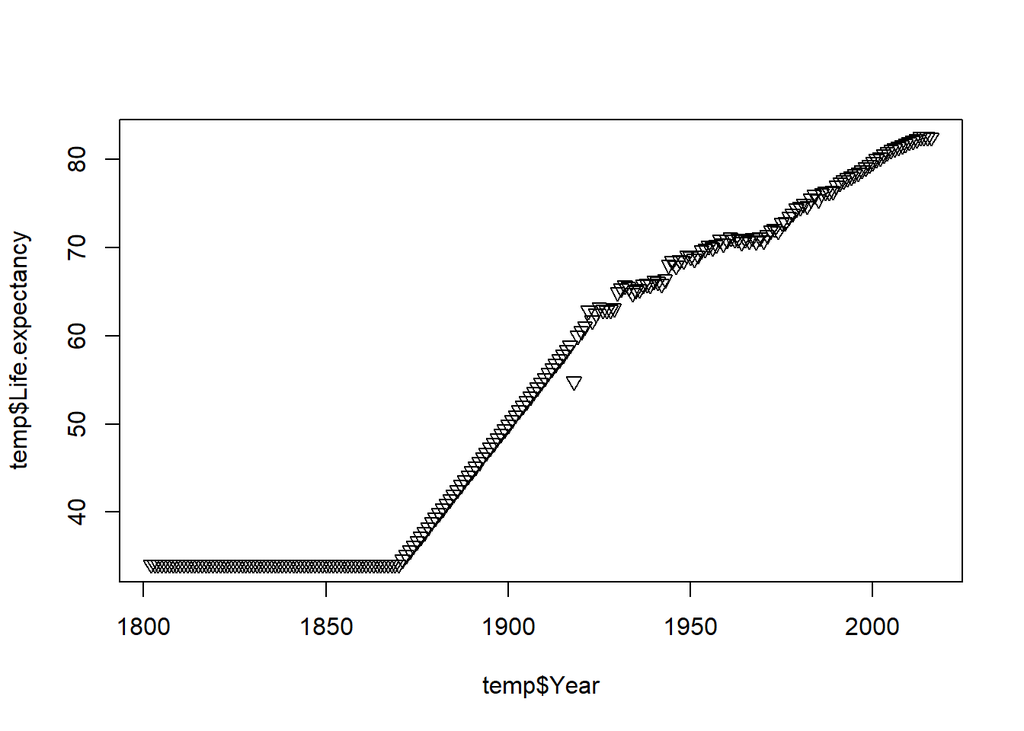

```r
temp = df %>% filter(df$Entity == "Australia")
plot(temp$Year, temp$Life.expectancy, pch = 25)
```

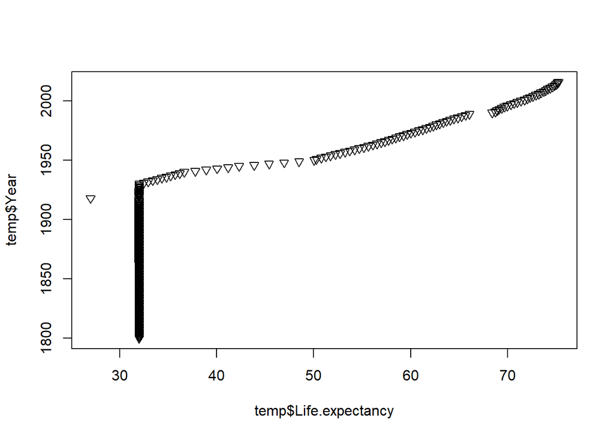

```r
temp = df %>% filter(df$Entity == "Brazil")
plot(temp$Life.expectancy, temp$Year, pch = 25)
```

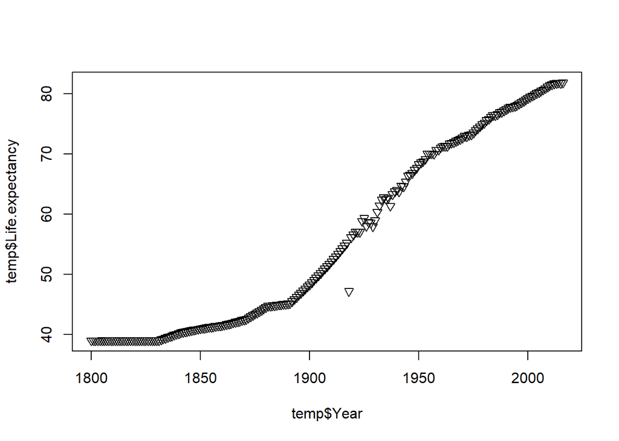

```r
temp = df %>% filter(df$Entity == "Canada")
plot(temp$Year, temp$Life.expectancy, pch = 25)
```

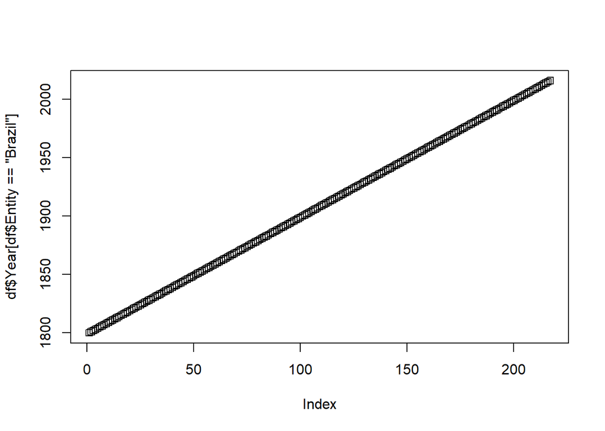

```r
with(df, plot(df$Year[df$Entity == 'Brazil'], pch = 0))
```

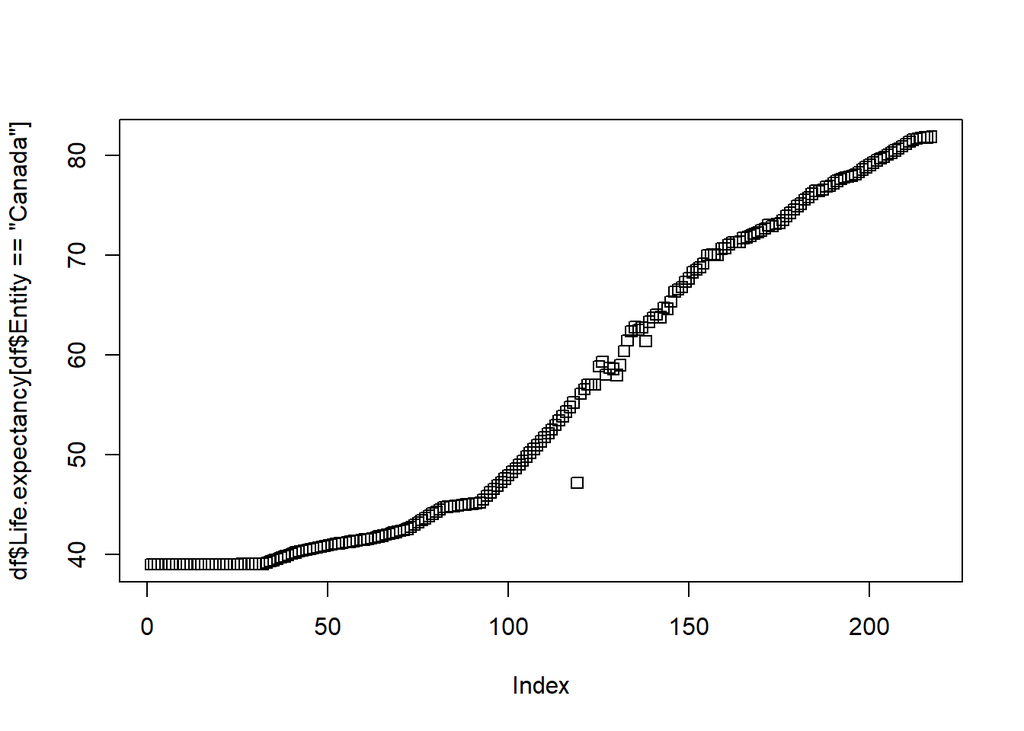

```r
with(df, plot(df$Life.expectancy[df$Entity == 'Canada'], pch = 0))
```

to get the particular values based on row

```r
with(df, (df$Life.expectancy[df$Entity == 'Brazil']))
```

```
##   [1] 32.00000 31.99981 31.99961 31.99942 31.99923 31.99903 31.99884 31.99865
##   [9] 31.99845 31.99826 31.99807 31.99787 31.99768 31.99749 31.99729 31.99710
##  [17] 31.99691 31.99671 31.99652 31.99633 31.99613 31.99594 31.99575 31.99555
##  [25] 31.99536 31.99517 31.99497 31.99478 31.99459 31.99439 31.99420 31.99401
##  [33] 31.99381 31.99362 31.99343 31.99323 31.99304 31.99285 31.99265 31.99246
##  [41] 31.99227 31.99207 31.99188 31.99169 31.99149 31.99130 31.99111 31.99091
##  [49] 31.99072 31.99053 31.99033 31.99014 31.98995 31.98975 31.98956 31.98937
##  [57] 31.98917 31.98898 31.98879 31.98859 31.98840 31.98821 31.98801 31.98782
##  [65] 31.98763 31.98743 31.98724 31.98705 31.98685 31.98666 31.98647 31.98627
##  [73] 31.98608 31.98589 31.98569 31.98550 31.98531 31.98511 31.98492 31.98473
##  [81] 31.98453 31.98434 31.98415 31.98395 31.98376 31.98357 31.98337 31.98318
##  [89] 31.98299 31.98279 31.98260 31.98241 31.98221 31.98202 31.98183 31.98163
##  [97] 31.98144 31.98125 31.98105 31.98086 31.98067 31.98047 31.98028 31.98009
## [105] 31.97989 31.97970 31.97951 31.97931 31.97912 31.97893 31.97873 31.97854
## [113] 31.97835 31.97815 31.97796 31.97777 31.97757 31.97738 26.97819 31.97699
## [121] 31.97680 31.97912 31.98144 31.98376 31.98608 31.98840 31.99072 31.99304
## [129] 31.99536 31.99768 32.00000 32.46407 32.92814 33.39222 33.85629 34.32036
## [137] 34.78443 35.24851 35.71258 36.17665 36.64072 37.77258 38.90443 40.03629
## [145] 41.16814 42.30000 43.84800 45.39600 46.94400 48.49200 50.04000 50.28000
## [153] 50.76300 51.24800 51.73700 52.23000 52.72500 53.22200 53.72000 54.21400
## [161] 54.70200 55.17900 55.64300 56.09100 56.52100 56.93500 57.33400 57.72200
## [169] 58.10500 58.48400 58.86500 59.25100 59.64400 60.04200 60.44300 60.84400
## [177] 61.23600 61.61500 61.97800 62.32800 62.66900 63.00800 63.35300 63.71000
## [185] 64.08100 64.46600 64.86200 65.26400 65.66700 66.06800 68.41000 68.74000
## [193] 68.91000 69.13000 69.38000 69.66000 69.96000 70.34000 70.67000 70.98000
## [201] 71.36000 71.76000 72.06000 72.33000 72.62000 72.93000 73.20000 73.46000
## [209] 73.72000 73.94000 74.15000 74.38000 74.64000 74.84000 75.01000 75.14000
## [217] 75.24000
```

```r
with(df, (df$Life.expectancy[df$Entity == 'Canada']))
```

```
##   [1] 39.00000 39.00149 39.00299 39.00449 39.00599 39.00748 39.00898 39.01048
##   [9] 39.01197 39.01347 39.01497 39.01646 39.01796 39.01946 39.02095 39.02245
##  [17] 39.02395 39.02544 39.02694 39.02844 39.02993 39.03143 39.03293 39.03443
##  [25] 39.03592 39.03742 39.03892 39.04041 39.04191 39.04341 39.04490 39.04640
##  [33] 39.17348 39.30056 39.42764 39.55472 39.68180 39.80888 39.93596 40.06304
##  [41] 40.19012 40.31720 40.39145 40.46569 40.53994 40.61419 40.68844 40.76269
##  [49] 40.83694 40.91118 40.98543 41.05968 41.11322 41.16675 41.22029 41.27382
##  [57] 41.32736 41.38090 41.43443 41.48797 41.54150 41.59504 41.69122 41.78739
##  [65] 41.88357 41.97974 42.07592 42.17210 42.26827 42.36445 42.46063 42.55680
##  [73] 42.77410 42.99139 43.20869 43.42598 43.64328 43.86058 44.07787 44.29517
##  [81] 44.51246 44.72976 44.77420 44.81864 44.86308 44.90752 44.95196 44.99640
##  [89] 45.04084 45.08528 45.12972 45.17416 45.52019 45.86622 46.21226 46.55829
##  [97] 46.90432 47.25035 47.59638 47.94242 48.28845 48.63448 49.02210 49.40971
## [105] 49.79733 50.18494 50.57256 50.96017 51.34779 51.73541 52.12302 52.51064
## [113] 52.96158 53.41251 53.86345 54.31438 54.76532 55.21625 47.16997 56.11813
## [121] 56.56907 57.02000 57.02000 57.02000 58.83000 59.31000 57.99000 58.68000
## [129] 58.57000 57.97000 58.95000 60.36000 61.43000 62.36000 62.77000 62.49000
## [137] 62.72000 61.35000 63.31000 63.74000 64.01000 63.76000 64.70000 64.61000
## [145] 65.35000 66.33000 66.53000 66.78000 67.33000 67.65000 68.28000 68.55000
## [153] 68.75000 69.13000 69.99000 70.05000 70.04000 69.96000 70.62000 70.66000
## [161] 71.04000 71.27000 71.30000 71.31000 71.69000 71.79000 71.92000 72.13000
## [169] 72.29000 72.45000 72.65000 72.98000 72.88000 73.11000 73.19000 73.49000
## [177] 73.92000 74.21000 74.54000 74.90000 75.14000 75.55000 75.76000 76.13000
## [185] 76.43000 76.41000 76.56000 76.86000 76.93000 77.20000 77.43000 77.61000
## [193] 77.76000 77.82000 77.93000 78.07000 78.31000 78.57000 78.78000 79.01000
## [201] 79.26000 79.48000 79.66000 79.84000 80.05000 80.23000 80.48000 80.65000
## [209] 80.87000 81.12000 81.34000 81.53000 81.66000 81.75000 81.79000 81.77000
## [217] 81.85000
```

```r
with(df, (df$Year[df$Entity == 'Brazil']))
```

```
##   [1] 1800 1801 1802 1803 1804 1805 1806 1807 1808 1809 1810 1811 1812 1813 1814
##  [16] 1815 1816 1817 1818 1819 1820 1821 1822 1823 1824 1825 1826 1827 1828 1829
##  [31] 1830 1831 1832 1833 1834 1835 1836 1837 1838 1839 1840 1841 1842 1843 1844
##  [46] 1845 1846 1847 1848 1849 1850 1851 1852 1853 1854 1855 1856 1857 1858 1859
##  [61] 1860 1861 1862 1863 1864 1865 1866 1867 1868 1869 1870 1871 1872 1873 1874
##  [76] 1875 1876 1877 1878 1879 1880 1881 1882 1883 1884 1885 1886 1887 1888 1889
##  [91] 1890 1891 1892 1893 1894 1895 1896 1897 1898 1899 1900 1901 1902 1903 1904
## [106] 1905 1906 1907 1908 1909 1910 1911 1912 1913 1914 1915 1916 1917 1918 1919
## [121] 1920 1921 1922 1923 1924 1925 1926 1927 1928 1929 1930 1931 1932 1933 1934
## [136] 1935 1936 1937 1938 1939 1940 1941 1942 1943 1944 1945 1946 1947 1948 1949
## [151] 1950 1951 1952 1953 1954 1955 1956 1957 1958 1959 1960 1961 1962 1963 1964
## [166] 1965 1966 1967 1968 1969 1970 1971 1972 1973 1974 1975 1976 1977 1978 1979
## [181] 1980 1981 1982 1983 1984 1985 1986 1987 1988 1989 1990 1991 1992 1993 1994
## [196] 1995 1996 1997 1998 1999 2000 2001 2002 2003 2004 2005 2006 2007 2008 2009
## [211] 2010 2011 2012 2013 2014 2015 2016
```

to creates a matrix of scatter plots.

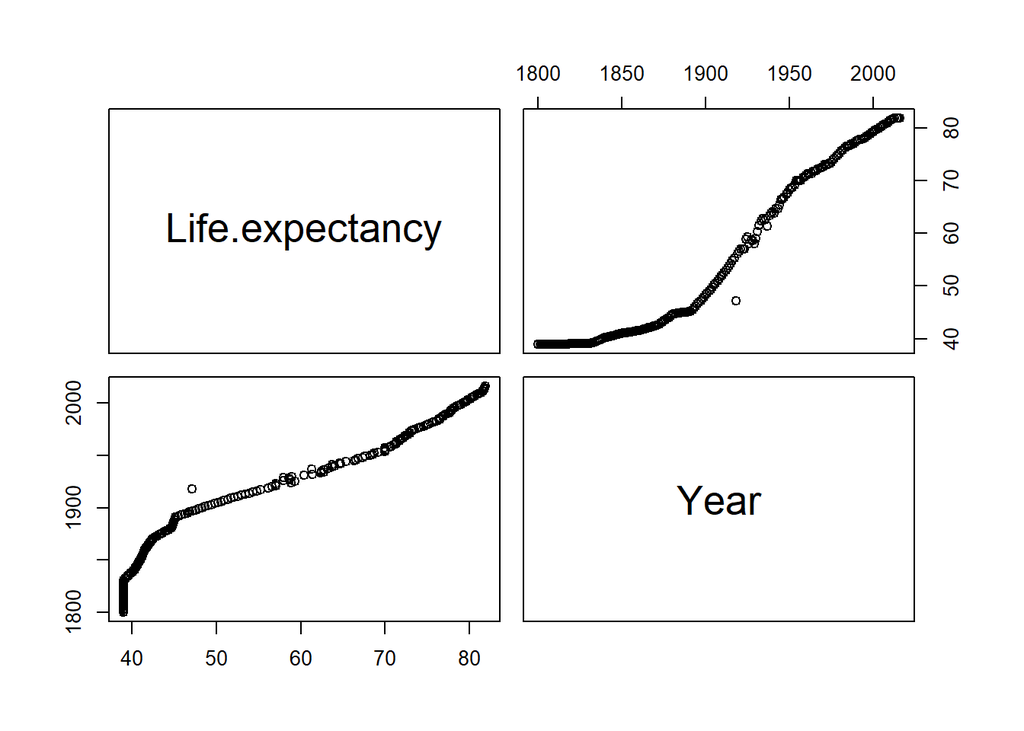

```r
pairs(~ Life.expectancy + Year, data = temp)
```

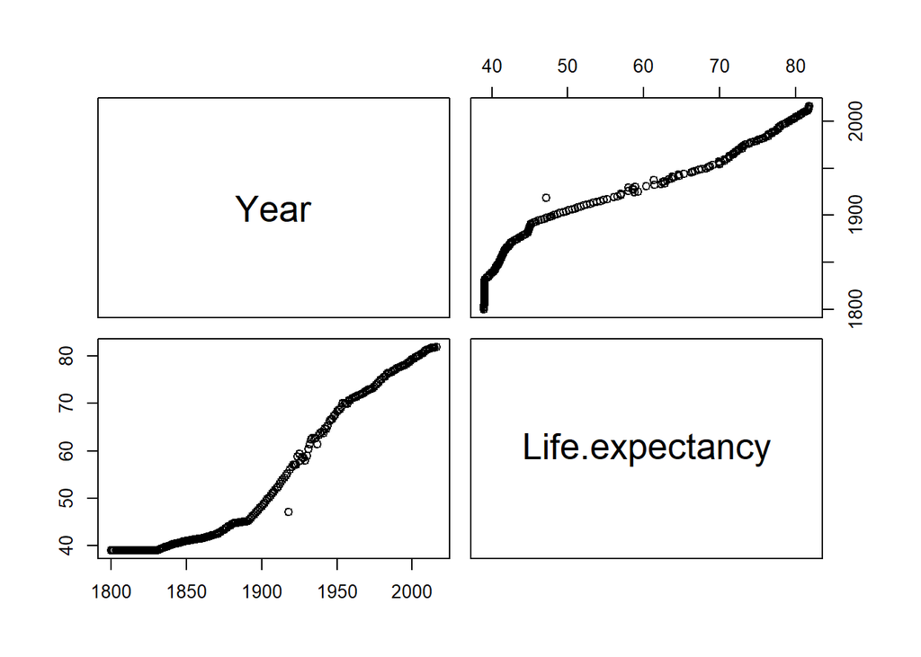

```r
pairs(~Year  + Life.expectancy, data = temp)
```

Line plot

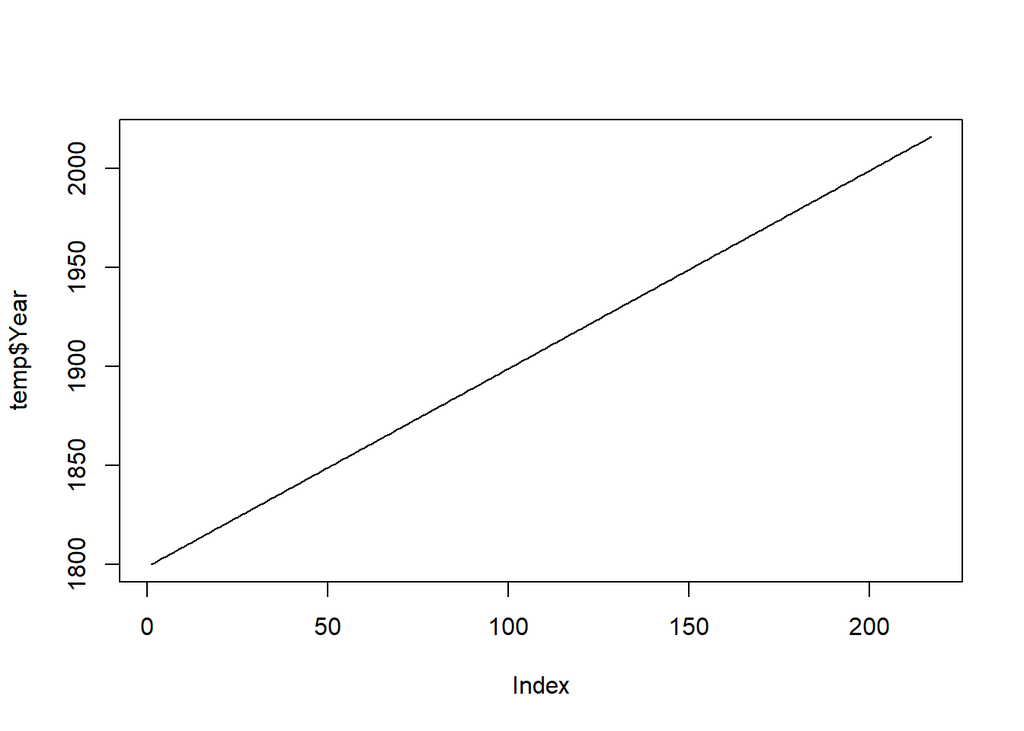

```r
plot(temp$Year, type = 'l' )
```

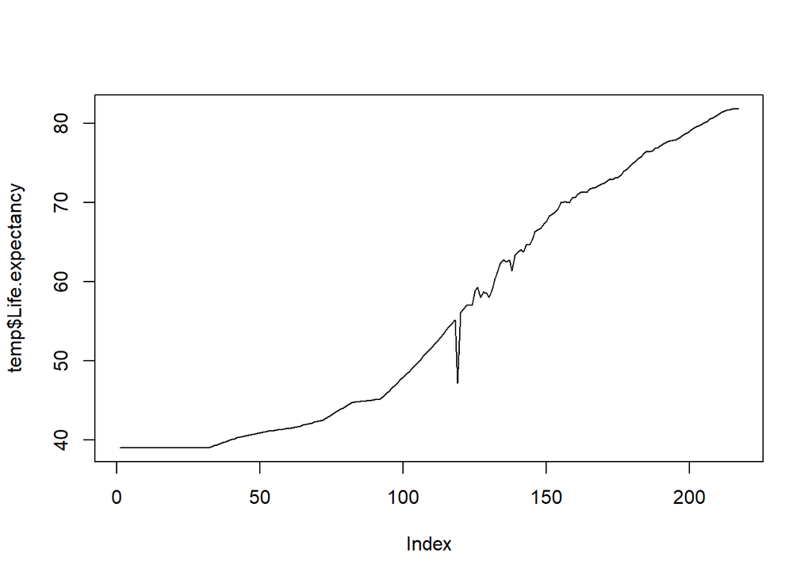

```r
plot(temp$Life.expectancy, type = 'l' )
```

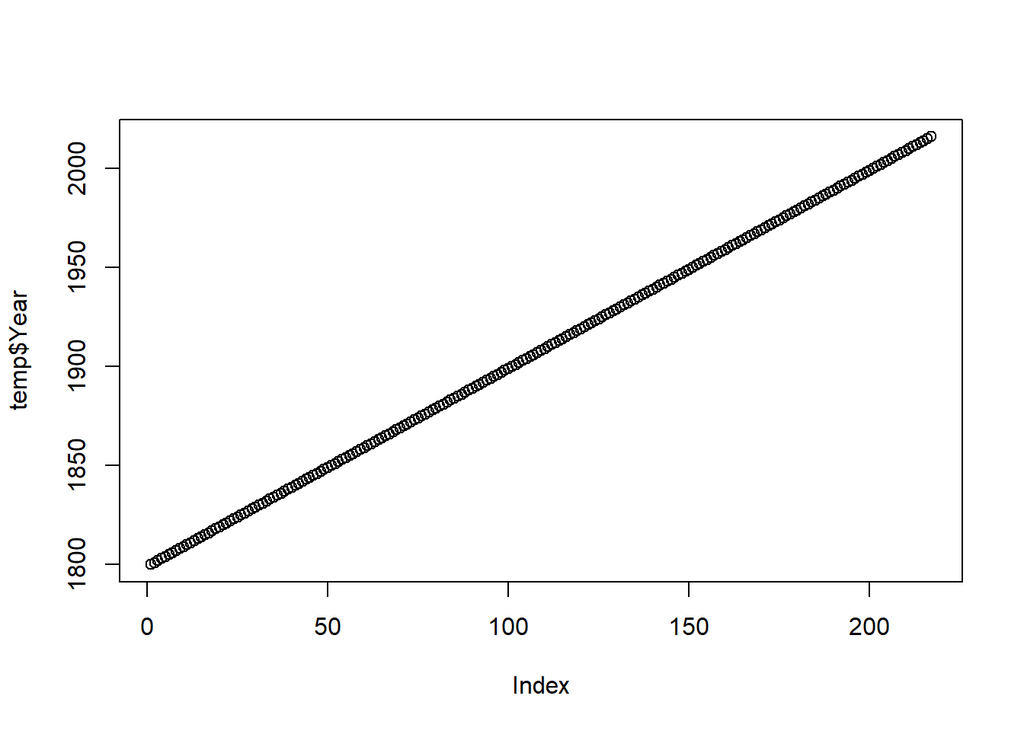

```r
plot(temp$Year, type = 'b')
```